```python
import math
```

# Week 3

## Quiz

1. What is the difference between a list and a tuple?
2. Given a list `my_list`, how can you access the last item in the list?
3. Why does the while look below go on forever?

```python
n=0
while n < 20:
    print(n)
```

1. Identify and correct the error.

```python
import math
sin(0)
```

```
---------------------------------------------------------------------------
NameError                                 Traceback (most recent call last)
~\AppData\Local\Temp/ipykernel_12764/2097557198.py in <module>
      1 import math
----> 2 sin(0)

NameError: name 'sin' is not defined
```

#### Answers:

1. Lists are mutable while tuples are immutable.

```python
my_list = [3,76,2,395,492,49]
```

```python
my_list[-1]
```

```
49
```

```python
my_list.reverse()
```

```python
my_list[0]
```

```
49
```

```python
my_list.pop(len(my_list)-1)
```

```
3
```

```python
my_list
```

```
[49, 492, 395, 2, 76]
```

```python
n=0
while n < 20:
    print(n)
    n += 1
```

```
0
1
2
3
4
5
6
7
8
9
10
11
12
13
14
15
16
17
18
19
```

```python
math.sin(0)
```

```
0.0
```

## Notes

### Code comments

Comments can be added to code using the hashtag `#`

Python ignores any and all characters after the `#`

Criteria for code comments

1. describing what the line of code does
2. be specific
3. sort and to the point

```python
def Divisors(num):                       # Define divisors function with positive integer input
    list_of_divisors = []                # Define a list variable to store the divisors
    for div in range(1,num+1):           # loop through all possible divisors
        if num%div == 0:                 # check if div is a divisor
            list_of_divisors.append(div) # if it is, add it to the list of divisors
    return list_of_divisors              # return the list of divisors as output
```

For long comments or multi-line comments use triple quotes.

```python
"""This is a long comment that can be
entered onto a new line and continued
for as long as you would like"""
def IsPrime(num):                               # define function IsPrime with integer input num
    for div in range(2,int(math.sqrt(num)) +1): # loop through possible divisors of num, up to the square root
        if num%div == 0:                        # check if the loop variable is a divisor
            return False                        # if it is, then num is not prime and False is returned
    return True                                 # if we get through the loop, then no divisors and num is prime
```

### Project Report

Your target audience is just an average person. You should always be asking yourself, "What am I trying to tell the reader?"

#### Introduction

1. Background info and motivations
   - mathematical definitions
   - any other background from other fields
   - Why should the reader care?
   - Are there any applications?
2. Goals
   - What do you want the reader to take away from this project
3. Plan
   - How are you going to go about achieving the goals?
   - What are the steps you are going to take to get the reader to the final goal?

#### Narrative and Code

1. Results section

#### Conclusion

1. Remind reader of the goals
2. Review the procedure
3. Summarize the results

#### References

Everything that did not come out of your own gray matter needs to be cited in the text with a full reference listed here.

### Graphing using `matplotlib.pyplot`

```python
import matplotlib.pyplot as plt
```

```python
horiz = [n for n in range(11)]
horiz
```

```
[0, 1, 2, 3, 4, 5, 6, 7, 8, 9, 10]
```

```python
# This is the same as the above
horiz = []
for n in range(11):
    horiz.append(n)
horiz
```

```
[0, 1, 2, 3, 4, 5, 6, 7, 8, 9, 10]
```

```python
vert = [h**2 - 3*h+7 for h in horiz]
vert
```

```
[7, 5, 5, 7, 11, 17, 25, 35, 47, 61, 77]
```

```python
vert = []
for h in horiz:
    vert.append(h**2 - 3*h+7)
vert
```

```
[7, 5, 5, 7, 11, 17, 25, 35, 47, 61, 77]
```

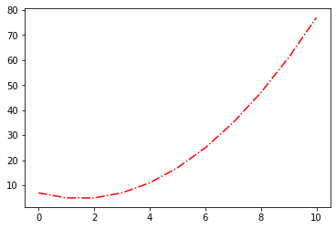

```python
plt.plot(horiz,vert,'r-.')
plt.show()
```

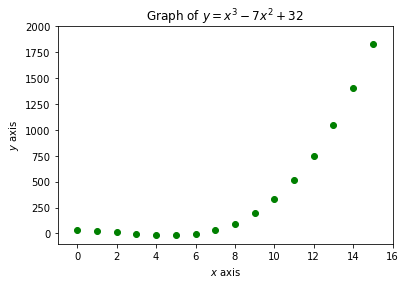

```python
x = [i for i in range(20)]
y = [i**3 - 7*i**2 + 32 for i in x]
plt.plot(x,y,'go')
plt.title('Graph of $ y= x^3-7x^2+32 $')
plt.xlabel('$x$ axis')
plt.ylabel('$y$ axis')
plt.xlim([-1,16])
plt.ylim([-100,2000])
plt.show()
```

```python
import math
```

```python
x_vals = [math.pi*n/25 - 2*math.pi for n in range(101)]
y_vals = [math.cos(x) for x in x_vals]
```

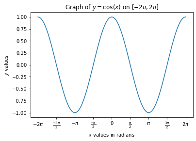

```python
plt.plot(x_vals,y_vals)
plt.title('Graph of $ y = \cos(x) $ on $ [-2\pi,2\pi] $')
plt.xlabel('$x$ values in radians')
plt.ylabel('$y$ values')
xticklocs = [math.pi*n/2 - 2*math.pi for n in range(9)]
xticklabs = ['$-2\pi$','$\\frac{-3\pi}{2}$','$-\pi$','$\\frac{-\pi}{2}$','0',
             '$\\frac{\pi}{2}$','$\pi$','$\\frac{3\pi}{2}$','$2\pi$']
plt.xticks(xticklocs,xticklabs)
plt.show()
```

### Project 2